# Week 3: Lab - Visualization

# Instructions

In Chapter 12, we explored many different ways to “look at” the numbers. For this lab, let’s explore the `mtcars` dataset that is included within R.

This activity description does not provide the same level of code prompts as previous labs – it is assumed that you remember or can look up the necessary code. The overall goal of this activity is to use `ggplot2` to show different attributes of the `mtcars` dataset. Please be sure to include both the code and the images that were generated with your assignment.

Add all of your libraries that you use for this assignment here.

```r
# Add your library below.

library(ggplot2)
```

# Generate the following visualizations:

## Step 1 - Histogram

Histogram of `mpg`

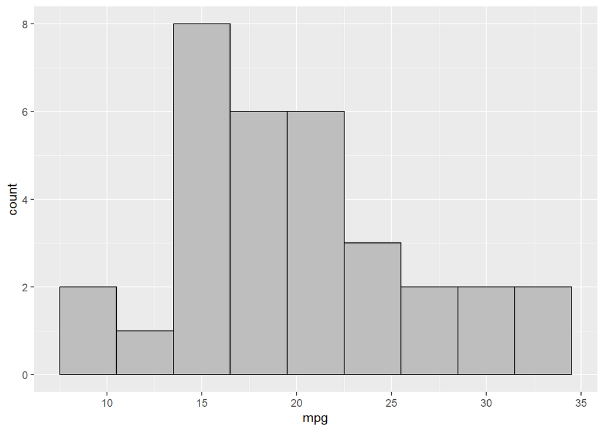

```r
# Write your code below.
ggplot(mtcars, aes(x = mpg)) + geom_histogram(binwidth = 3, color = "black", fill = "grey")
```

## Step 2 - Boxplots

Boxplots of `mpg` by `cyl` (i.e. 3 box plots: one for all cars with 4 cylinders, one for all cars with 6 cylinders, and one with all the cars with 8 cylinders).

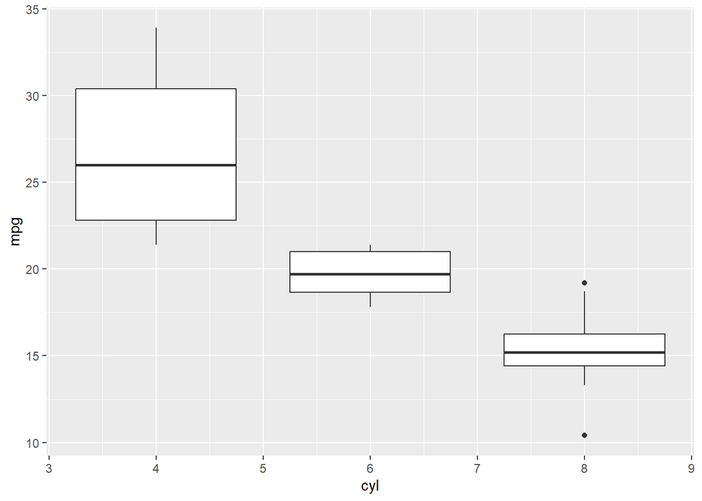

```r
# Write your code below.
ggplot(mtcars, aes(group = cyl, x = cyl, y = mpg)) + geom_boxplot()
```

## Step 3 - MultiLine chart

MultiLine chart of `wt` on the x-axis, `mpg` for the y-axis. With a line for each `am` (i.e. two lines). Also be sure to show each point on the chart.

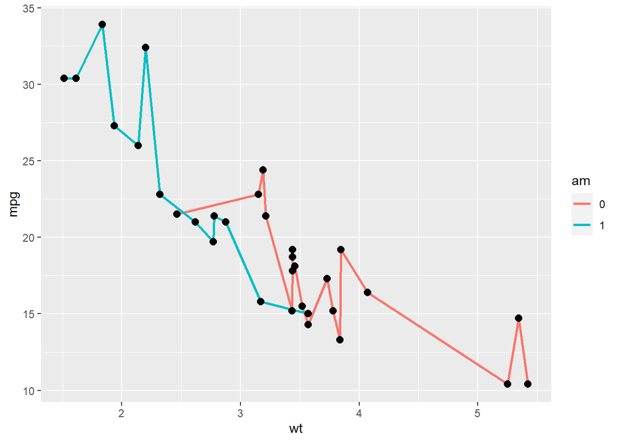

```r
# Write your code below.
mtcars$am <- as.factor(mtcars$am)
ggplot(mtcars, aes(x = wt, y = mpg, group = am, color = am)) + geom_line(size = 1) +geom_point(color = "black", size = 2.5)
```

## Step 4 - Barchart

Barchart with the x-axis being the name of each car, and the height being `wt`. Make sure to rotate the x-axis labels, so we can actually read the car name.

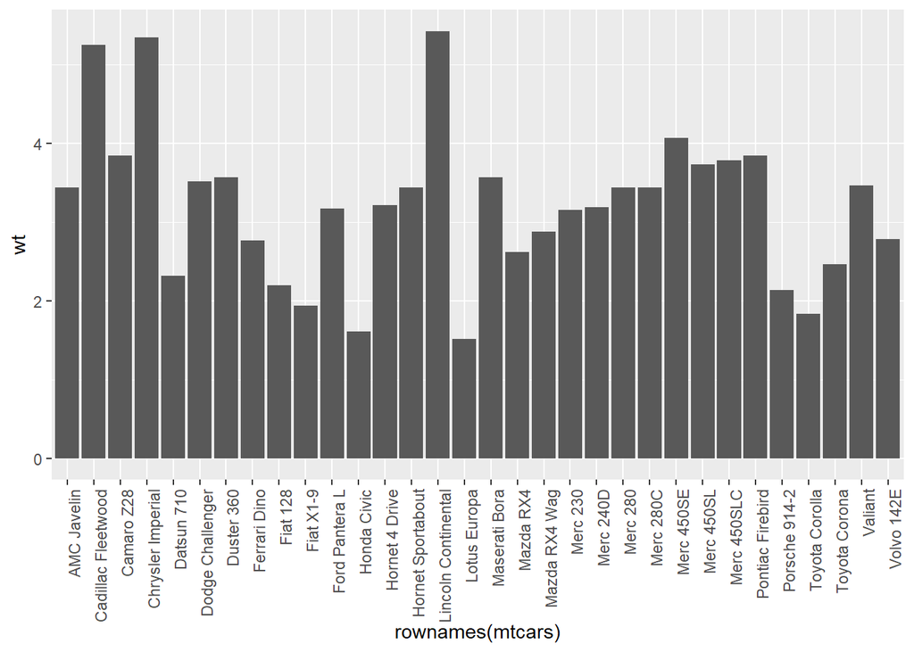

```r
# Write your code below.
ggplot(mtcars, aes(rownames(mtcars), y = wt)) + geom_bar(stat = "identity") + theme(axis.text.x = element_text(angle = 90, hjust = 1))
```

## Step 5 - Scatter chart

Scatter chart with the x-axis being the `mpg` and the y-axis being the `wt` of the car. Have the color and the size of each “symbol” (i.e., circle) represent how fast the car goes (based on the `qsec` attribute).

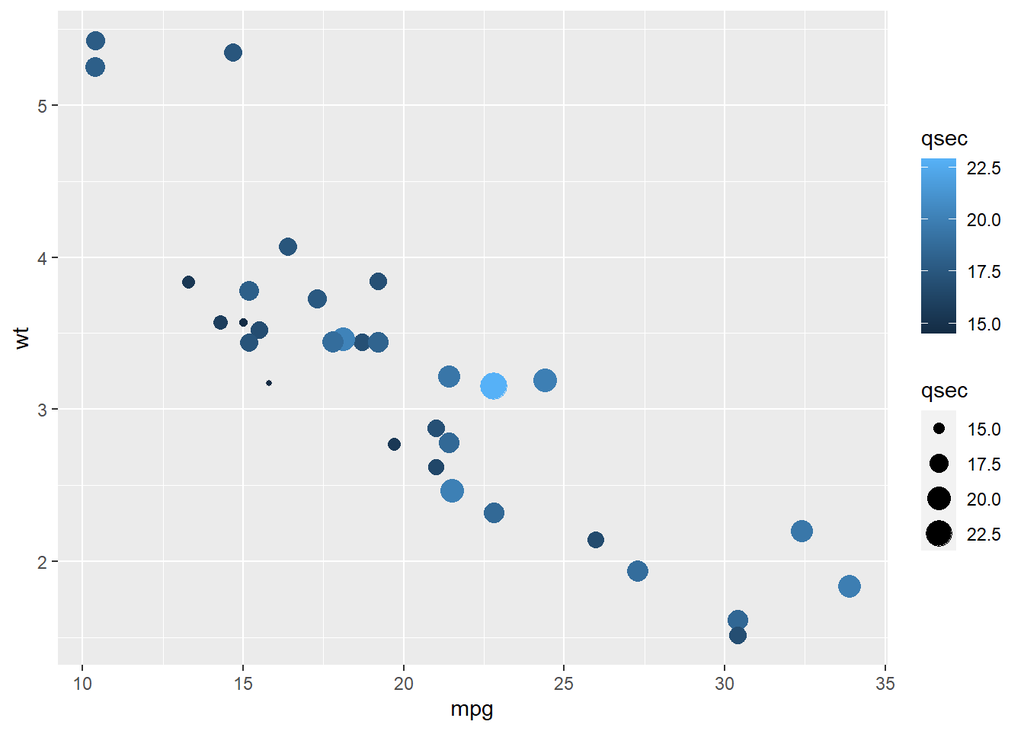

```r
# Write your code below.
ggplot(mtcars, aes(x = mpg, y = wt)) + geom_point(aes(size = qsec, color = qsec))
```